# Введение в дисперсионный анализ (ANOVA)

# Возможные методы: попарные t-тесты. Оценка эффективности препаратов

| 0 | A | B | AB |
| --- | --- | --- | --- |
| 3,901.40 | 2,779.00 | 2,241.57 | 1,998.17 |

Методы: используем двухвыборочный t-тест для сравнения групп.

- Сравнение A vs. 0: эффект препарата А
- Сравнение B vs. 0: эффект препарата B

Какими вообще могут быть эффекты?

Нет эффекта / ухудшает течение болезни / улучшает течение болезни.

Дополнительно:

- Сравнение A vs. B: какой препарат лучше?

# Возможные методы: попарные t-тесты. Оценка эффективности комбинированной терапии

| 0 | A | B | AB |
| --- | --- | --- | --- |
| 3,901.40 | 2,779.00 | 2,241.57 | 1,998.17 |

Методы: используем двухвыборочный t-тест для сравнения групп.

- Сравнение AB vs 0: проверим общий эффект комбинированной терапии
- Сравнение AB vs A: добавляет ли что-то комбинированная терапия по отношению к терапии только препаратом А?
- Сравнение AB vs. B: добавляет ли что-то комбинированная терапия по отношению к терапии только препаратом B?

# Возможные методы: попарные t-тесты. Оценка эффективности комбинированной терапии

| 0 | A | B | AB |
| --- | --- | --- | --- |
| 3,901.40 | 2,779.00 | 2,241.57 | 1,998.17 |

Методы: используем двухвыборочный t-тест для сравнения групп.

- Сравнение AB vs 0: проверим общий эффект комбинированной терапии
- Сравнение AB vs A: добавляет ли что-то комбинированная терапия по отношению к терапии только препаратом А?
- Сравнение AB vs. B: добавляет ли что-то комбинированная терапия по отношению к терапии только препаратом B?

*Оценить синергический эффект препаратов A+B*

# Возможные методы: попарные t-тесты. Оценка эффективности комбинированной терапии

| 0 | A | B | AB |
| --- | --- | --- | --- |
| 3,901.40 | 2,779.00 | 2,241.57 | 1,998.17 |

Методы: используем двухвыборочный t-тест для сравнения групп.

- Сравнение AB vs 0: проверим общий эффект комбинированной терапии
- Сравнение AB vs A: добавляет ли что-то комбинированная терапия по отношению к терапии только препаратом А?
- Сравнение AB vs. B: добавляет ли что-то комбинированная терапия по отношению к терапии только препаратом B?

*Оценить синергический эффект препаратов A+B*

По идее “эффект синергии” – это разница между эффектом A + эффектом B и эффектом в группе AB. Но эту величину мы не можем оценить с помощью t-тестов.

**Проблема**: только косвенная оценка синергии.

# Попарные t-тесты. Плюсы и минусы

| 0 | A | B | AB |
| --- | --- | --- | --- |
| 3,901.40 | 2,779.00 | 2,241.57 | 1,998.17 |

Каковы плюсы и минусы такого метода?

# Попарные t-тесты. Плюсы и минусы

| 0 | A | B | AB |
| --- | --- | --- | --- |
| 3,901.40 | 2,779.00 | 2,241.57 | 1,998.17 |

**Плюсы:**

- Простой и понятный метод
- Легко интерпретировать результаты

**Минусы:**

- Проблема множественных сравнений: нужны поправки, которые ведут к потере мощности
- Неполное использование данных: для оценки эффекта препарата A не используем группу AB
- Не можем оценить синергию препаратов: только косвенные свидетельства

# Возможные методы: линейная модель + ANOVA

| 0 | A | B | AB |
| --- | --- | --- | --- |
| 3,901.40 | 2,779.00 | 2,241.57 | 1,998.17 |

```r
m1 <- lm(value ~ therapy, data = bdr)

m1 %>% anova
```

```
## Analysis of Variance Table
##
## Response: value
##           Df   Sum Sq Mean Sq F value    Pr(>F)
## therapy    3 21487143 7162381  14.581 2.243e-06 ***
## Residuals 36 17684040  491223
## ---
## Signif. codes:  0 '***' 0.001 '**' 0.01 '*' 0.05 '.' 0.1 ' ' 1
```

# Возможные методы: линейная модель + ANOVA

| 0 | A | B | AB |
| --- | --- | --- | --- |
| 3,901.40 | 2,779.00 | 2,241.57 | 1,998.17 |

```r
m1 %>% anova
```

```
## Analysis of Variance Table
##
## Response: value
##           Df   Sum Sq Mean Sq F value    Pr(>F)
## therapy    3 21487143 7162381  14.581 2.243e-06 ***
## Residuals 36 17684040  491223
## ---
## Signif. codes:  0 '***' 0.001 '**' 0.01 '*' 0.05 '.' 0.1 ' ' 1
```

Посмотрим на описание модели. Что значат коэффициенты регрессоров?

```r
m1 %>% summary
```

```
##
## Call:
## lm(formula = value ~ therapy, data = bdr)
##
## Residuals:
##     Min      1Q  Median      3Q     Max
## -1262.0  -519.5  -138.9   553.0  1524.3
##
## Coefficients:
##             Estimate Std. Error t value Pr(>|t|)
## (Intercept)   3901.4      221.6  17.603  < 2e-16 ***
## therapyA     -1122.4      313.4  -3.581    0.001 **
## therapyB     -1659.8      313.4  -5.296 6.07e-06 ***
## therapyAB    -1903.2      313.4  -6.072 5.57e-07 ***
## ---
## Signif. codes:  0 '***' 0.001 '**' 0.01 '*' 0.05 '.' 0.1 ' ' 1
##
## Residual standard error: 700.9 on 36 degrees of freedom
## Multiple R-squared:  0.5485, Adjusted R-squared:  0.5109
## F-statistic: 14.58 on 3 and 36 DF,  p-value: 2.243e-06
```

# Возможные методы: линейная модель + ANOVA

| 0 | A | B | AB |
| --- | --- | --- | --- |
| 3,901.40 | 2,779.00 | 2,241.57 | 1,998.17 |

Посмотрим на описание модели. Что значат коэффициенты регрессоров?

```r
m1 %>% summary
```

```
##
## Call:
## lm(formula = value ~ therapy, data = bdr)
##
## Residuals:
##     Min      1Q  Median      3Q     Max
## -1262.0  -519.5  -138.9   553.0  1524.3
##
## Coefficients:
##             Estimate Std. Error t value Pr(>|t|)
## (Intercept)   3901.4      221.6  17.603  < 2e-16 ***
## therapyA     -1122.4      313.4  -3.581    0.001 **
## therapyB     -1659.8      313.4  -5.296 6.07e-06 ***
## therapyAB    -1903.2      313.4  -6.072 5.57e-07 ***
## ---
## Signif. codes:  0 '***' 0.001 '**' 0.01 '*' 0.05 '.' 0.1 ' ' 1
##
## Residual standard error: 700.9 on 36 degrees of freedom
## Multiple R-squared:  0.5485, Adjusted R-squared:  0.5109
## F-statistic: 14.58 on 3 and 36 DF,  p-value: 2.243e-06
```

- `(Intercept)` – средний объем опухоли в группе плацебо
- `therapyA` – разница в среднем объеме опухоли между группой А и плацебо, т.е. эффект препарата А на средний объем опухоли
- `therapyB` – разница в среднем объеме опухоли между группой B и плацебо
- `therapyAB` – разница в среднем объеме опухоли между группой с комбинированной терапией и плацебо

# Но я хочу доверительные интервалы! Post hoc анализ

1. Обычно практикуемый подход: запустить F-test, в случае маленького p-value разбираться подробнее (поэтому post hoc).
2. Специальный случай: есть процедуры, контролирующие FWER, более сильные чем Бонферрони, Холм и Ко.
3. Процедур много: Даннетт, Тьюки, доверительные эллипсоиды, дуальные к F-тесту…

Мы остановимся на относительно новой процедуре: процедура Хоторна-Бретца-Вестфала (Hothorn, Bretz, Westfall), основанной на многомерном t-распределении.

Итак, мы хотим доверительные интервалы для разницы в размере опухоли; попарно сравнить группы с разной терапией; контролировать FWER.

Стартуем со стандартными предположениями: **нормальность** и **гомоскедастичность**.

# Но я хочу доверительные интервалы! Post hoc анализ

Еще раз проверим, что **терапия** на поле *ассоциирована* со *средним размером опухоли*.

```r
aov(value ~ therapy, data = bdr) %>% summary
```

```
##             Df   Sum Sq Mean Sq F value   Pr(>F)
## therapy      3 21487143 7162381   14.58 2.24e-06 ***
## Residuals   36 17684040  491223
## ---
## Signif. codes:  0 '***' 0.001 '**' 0.01 '*' 0.05 '.' 0.1 ' ' 1
```

```r
oneway.test(value ~ therapy, data = bdr)
```

```
##
##  One-way analysis of means (not assuming equal variances)
##
## data:  value and therapy
## F = 13.685, num df = 3.000, denom df = 19.808, p-value = 4.589e-05
```

# Но я хочу доверительные интервалы! Post hoc анализ

Можем приступить к post hoc анализу.

```r
library(multcomp)
```

```r
m1 <- bdr %>% lm(value ~ therapy, data = .)
HBW.comp <- m1 %>% multcomp::glht(linfct = mcp(therapy = "Tukey"))
```

Tukey сигнализирует, что мы хотим сравнить каждую группу с каждой. **Анализ выполняется не методом Тьюки**, а методом Хоторна-Бретца-Вестфалла!

# Но я хочу доверительные интервалы! Post hoc анализ

Указанные доверительные интервалы и p-values уже рассчитаны с учетом необходимости контролировать FWER.

Помним, что чем меньше опухоль, тем лучше.

```r
HBW.comp %>% summary()
```

```
##
##   Simultaneous Tests for General Linear Hypotheses
##
## Multiple Comparisons of Means: Tukey Contrasts
##
##
## Fit: lm(formula = value ~ therapy, data = .)
##
## Linear Hypotheses:
##             Estimate Std. Error t value Pr(>|t|)
## A - 0 == 0   -1122.4      313.4  -3.581  0.00524 **
## B - 0 == 0   -1659.8      313.4  -5.296  < 0.001 ***
## AB - 0 == 0  -1903.2      313.4  -6.072  < 0.001 ***
## B - A == 0    -537.4      313.4  -1.715  0.33105
## AB - A == 0   -780.8      313.4  -2.491  0.07815 .
## AB - B == 0   -243.4      313.4  -0.777  0.86456
## ---
## Signif. codes:  0 '***' 0.001 '**' 0.01 '*' 0.05 '.' 0.1 ' ' 1
## (Adjusted p values reported -- single-step method)
```

# Но я хочу доверительные интервалы! Post hoc анализ

Указанные доверительные интервалы и p-values уже рассчитаны с учетом необходимости контролировать FWER.

Помним, что чем меньше опухоль, тем лучше.

```r
HBW.comp %>% confint()
```

```
##
##   Simultaneous Confidence Intervals
##
## Multiple Comparisons of Means: Tukey Contrasts
##
##
## Fit: lm(formula = value ~ therapy, data = .)
##
## Quantile = 2.6949
## 95% family-wise confidence level
##
##
## Linear Hypotheses:
##             Estimate   lwr        upr
## A - 0 == 0  -1122.4020 -1967.0858  -277.7182
## B - 0 == 0  -1659.8340 -2504.5178  -815.1502
## AB - 0 == 0 -1903.2250 -2747.9088 -1058.5411
## B - A == 0   -537.4320 -1382.1158   307.2518
## AB - A == 0  -780.8230 -1625.5068    63.8609
## AB - B == 0  -243.3910 -1088.0748   601.2929
```

# Но я хочу доверительные интервалы! Post hoc анализ

Красивые картиночки работают “из коробки”.

Указанные доверительные интервалы и p-values уже рассчитаны с учетом необходимости контролировать FWER.

Помним, что чем меньше опухоль, тем лучше.

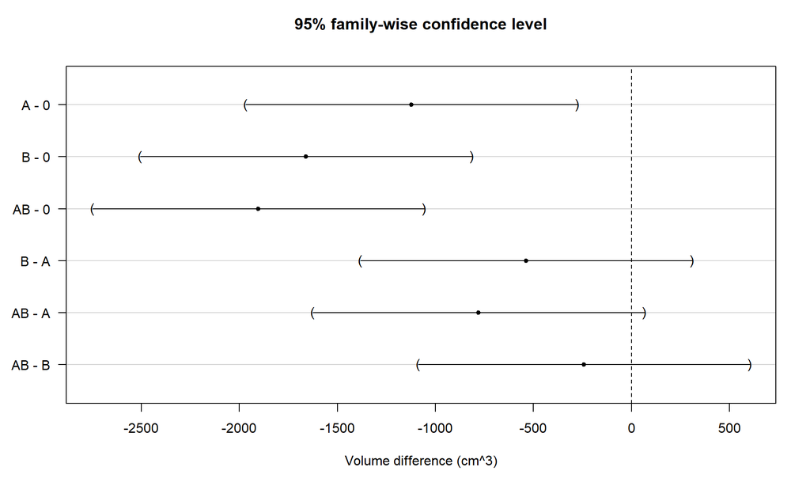

```r
HBW.comp %>% plot(xlab = "Volume difference (cm^3)")
```

# Но я хочу доверительные интервалы! Post hoc анализ

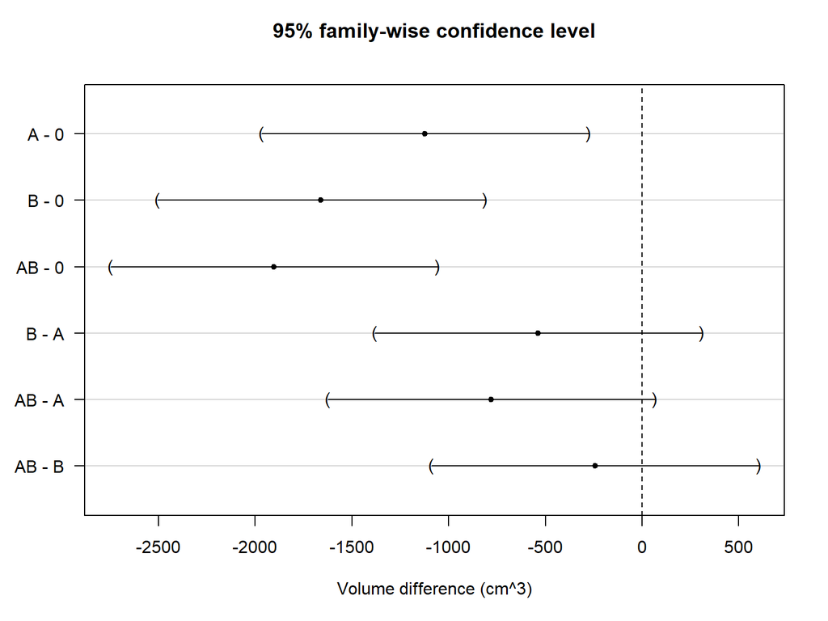

В случае, если соблюдены условия **нормальности** и **гомоскедастичности**, метод точный, т.е. работает и для малых выборок. Метод использует квантили многомерного t-распределения, которые считаются методом Монте-Карло. Если нужна 100% воспроизводимость, не забудьте использовать `set.seed`!

Это очень гибкий метод: можно не только попарно сравнивать группы между собой, можно тестировать любые наборы линейных гипотез. К сожалению, это за рамками сегодняшнего занятия.

Нарушение условий использования:

1. Если нарушено условие **нормальности**, то дополнительных телодвижений делать не нужно: для достаточно больших выборок метод работает (асимптотическая консистентность).
2. Если вдобавок нарушено условие **гомоскедастичности**, то нужно использовать робастную оценку ковариационной матрицы (сендвичи).

# Но я хочу доверительные интервалы! Post hoc анализ

```r
HBW.comp %>% summary
```

```
##
##   Simultaneous Tests for General Linear Hypotheses
##
## Multiple Comparisons of Means: Tukey Contrasts
##
##
## Fit: lm(formula = value ~ therapy, data = .)
##
## Linear Hypotheses:
##             Estimate Std. Error t value Pr(>|t|)
## A - 0 == 0   -1122.4      313.4  -3.581  0.00553 **
## B - 0 == 0   -1659.8      313.4  -5.296  < 0.001 ***
## AB - 0 == 0  -1903.2      313.4  -6.072  < 0.001 ***
## B - A == 0    -537.4      313.4  -1.715  0.33111
## AB - A == 0   -780.8      313.4  -2.491  0.07835 .
## AB - B == 0   -243.4      313.4  -0.777  0.86455
## ---
## Signif. codes:  0 '***' 0.001 '**' 0.01 '*' 0.05 '.' 0.1 ' ' 1
## (Adjusted p values reported -- single-step method)
```

**Задача:**

1. Провести количественную оценку противоопухолевой активности препаратов
2. Оценить эффект комбинированной терапии Препаратом A и Препаратом B
3. Оценить синергический эффект препаратов A+B

*Оценить синергический эффект препаратов A+B*

По идее “эффект синергии” – это разница между эффектом A + эффектом B и эффектом в группе AB. Можем ли мы оценить эту величину?

# Но я хочу доверительные интервалы! Post hoc анализ

*Оценить синергический эффект препаратов A+B*

По идее “эффект синергии” – это разница между эффектом A + эффектом B и эффектом в группе AB.

```r
HBW.synergy <-
  m1 %>% multcomp::glht(
    linfct = c(
      "therapyA = 0",
      "therapyB = 0",
      "therapyAB = 0",
      "therapyAB - therapyA - therapyB = 0"
    )
  )

HBW.comp %>% summary
```

```
##
##   Simultaneous Tests for General Linear Hypotheses
##
## Multiple Comparisons of Means: Tukey Contrasts
##
##
## Fit: lm(formula = value ~ therapy, data = .)
##
## Linear Hypotheses:
##             Estimate Std. Error t value Pr(>|t|)
## A - 0 == 0   -1122.4      313.4  -3.581  0.00512 **
## B - 0 == 0   -1659.8      313.4  -5.296  < 0.001 ***
## AB - 0 == 0  -1903.2      313.4  -6.072  < 0.001 ***
## B - A == 0    -537.4      313.4  -1.715  0.33128
## AB - A == 0   -780.8      313.4  -2.491  0.07868 .
## AB - B == 0   -243.4      313.4  -0.777  0.86454
## ---
## Signif. codes:  0 '***' 0.001 '**' 0.01 '*' 0.05 '.' 0.1 ' ' 1
## (Adjusted p values reported -- single-step method)
```

```r
HBW.synergy %>% summary
```

```
##
##   Simultaneous Tests for General Linear Hypotheses
##
## Fit: lm(formula = value ~ therapy, data = .)
##
## Linear Hypotheses:
##                                      Estimate Std. Error t value Pr(>|t|)
## therapyA == 0                         -1122.4      313.4  -3.581   0.0036 **
## therapyB == 0                         -1659.8      313.4  -5.296   <0.001 ***
## therapyAB == 0                        -1903.2      313.4  -6.072   <0.001 ***
## therapyAB - therapyA - therapyB == 0    879.0      443.3   1.983   0.1570
## ---
## Signif. codes:  0 '***' 0.001 '**' 0.01 '*' 0.05 '.' 0.1 ' ' 1
## (Adjusted p values reported -- single-step method)
```

```r
HBW.synergy %>% confint
```

```
##
##   Simultaneous Confidence Intervals
##
## Fit: lm(formula = value ~ therapy, data = .)
##
## Quantile = 2.5285
## 95% family-wise confidence level
##
##
## Linear Hypotheses:
##                                      Estimate   lwr        upr
## therapyA == 0                        -1122.4020 -1914.9285  -329.8755
## therapyB == 0                        -1659.8340 -2452.3605  -867.3075
## therapyAB == 0                       -1903.2250 -2695.7515 -1110.6984
## therapyAB - therapyA - therapyB == 0   879.0110  -241.7907  1999.8128
```

# ANOVA + post hocs. Плюсы и минусы

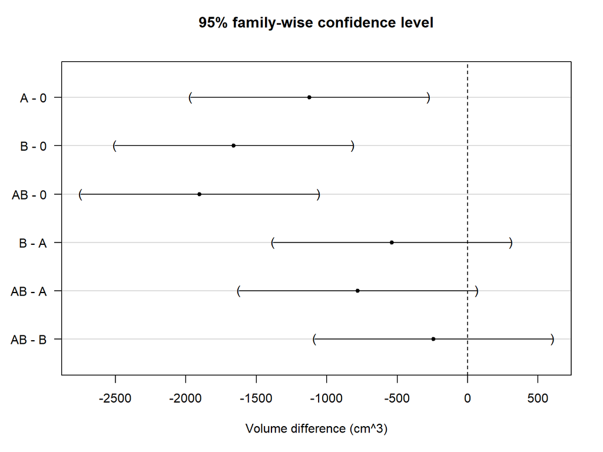

**Плюсы:**

- Автоматически контролирует FWER (по желанию можно отключить поправку)
- Легко интерпретировать результаты
- Можем оценить синергию препаратов

**Минусы:**

- Метод менее прямолинеен по сравнению с t-тестами
- Неполное использование данных: для оценки эффекта препарата A не используем группу AB
- Оценка синергии требует дополнительных телодвижений

# Two-Way ANOVA

| 0 | A | B | AB |
| --- | --- | --- | --- |
| 3,901.40 | 2,779.00 | 2,241.57 | 1,998.17 |

Давайте изменим взгляд на наши данные.

```r
bdr <- bdr %>% mutate(
  A = ifelse(therapy %in% c("A", "AB"), "Yes", "No"),
  B = ifelse(therapy %in% c("B", "AB"), "Yes", "No")
)
```

```r
bdr %>% glimpse
```

```
## Rows: 40
## Columns: 4
## $ therapy <fct> 0, 0, 0, 0, 0, 0, 0, 0, 0, 0, A, A, A, A, A, A, A, A, A, A, B,…
## $ value   <dbl> 3147.774, 5425.740, 4302.948, 3759.539, 3378.191, 4949.150, 34…
## $ A       <chr> "No", "No", "No", "No", "No", "No", "No", "No", "No", "No", "Y…
## $ B       <chr> "No", "No", "No", "No", "No", "No", "No", "No", "No", "No", "N…
```

```r
bdr %>% group_by(A, B) %>% summarise(mean = mean(value)) %>%
  pivot_wider(names_from = A, names_prefix = "A", values_from = mean) %>% gt
```

| B | ANo | AYes |
| --- | --- | --- |
| No | 3901.399 | 2778.997 |
| Yes | 2241.565 | 1998.174 |

# Two-Way ANOVA

| 0 | A | B | AB |
| --- | --- | --- | --- |
| 3,901.40 | 2,779.00 | 2,241.57 | 1,998.17 |

```r
bdr %>% group_by(A, B) %>% summarise(mean = mean(value)) %>%
  pivot_wider(names_from = A, names_prefix = "A", values_from = mean) %>% gt
```

| B | ANo | AYes |
| --- | --- | --- |
| No | 3901.399 | 2778.997 |
| Yes | 2241.565 | 1998.174 |

Что значат коэффициенты в такой модели?

```r
mA_B <- bdr %>% lm(value ~ A + B, data = .)

mA_B %>% summary
```

```
##
## Call:
## lm(formula = value ~ A + B, data = .)
##
## Residuals:
##     Min      1Q  Median      3Q     Max
## -1481.7  -432.9  -187.4   462.0  1744.1
##
## Coefficients:
##             Estimate Std. Error t value Pr(>|t|)
## (Intercept)   3681.6      199.4  18.463  < 2e-16 ***
## AYes          -682.9      230.3  -2.966  0.00526 **
## BYes         -1220.3      230.3  -5.300 5.56e-06 ***
## ---
## Signif. codes:  0 '***' 0.001 '**' 0.01 '*' 0.05 '.' 0.1 ' ' 1
##
## Residual standard error: 728.1 on 37 degrees of freedom
## Multiple R-squared:  0.4992, Adjusted R-squared:  0.4722
## F-statistic: 18.44 on 2 and 37 DF,  p-value: 2.775e-06
```

# Two-Way ANOVA

| 0 | A | B | AB |
| --- | --- | --- | --- |
| 3,901.40 | 2,779.00 | 2,241.57 | 1,998.17 |

```r
bdr %>% group_by(A, B) %>% summarise(mean = mean(value)) %>%
  pivot_wider(names_from = A, names_prefix = "A", values_from = mean) %>% gt
```

| B | ANo | AYes |
| --- | --- | --- |
| No | 3901.399 | 2778.997 |
| Yes | 2241.565 | 1998.174 |

Что значат коэффициенты в такой модели?

```r
mA_B <- bdr %>% lm(value ~ A + B, data = .)

mA_B %>% summary
```

```
##
## Call:
## lm(formula = value ~ A + B, data = .)
##
## Residuals:
##     Min      1Q  Median      3Q     Max
## -1481.7  -432.9  -187.4   462.0  1744.1
##
## Coefficients:
##             Estimate Std. Error t value Pr(>|t|)
## (Intercept)   3681.6      199.4  18.463  < 2e-16 ***
## AYes          -682.9      230.3  -2.966  0.00526 **
## BYes         -1220.3      230.3  -5.300 5.56e-06 ***
## ---
## Signif. codes:  0 '***' 0.001 '**' 0.01 '*' 0.05 '.' 0.1 ' ' 1
##
## Residual standard error: 728.1 on 37 degrees of freedom
## Multiple R-squared:  0.4992, Adjusted R-squared:  0.4722
## F-statistic: 18.44 on 2 and 37 DF,  p-value: 2.775e-06
```

- `(Intercept)` – средний размер опухоли в группе плацебо
- `(AYes)` – эффект препарата А, разница между средним размером опухоли в группе А и плацебо
- `(BYes)` – эффект препарата B

Каков эффект комбинированной терапии? Иными словами, как посчитать средний размер опухоли в группе AB?

# Two-Way ANOVA

Что значат коэффициенты в такой модели?

```
##
## Call:
## lm(formula = value ~ A + B, data = .)
##
## Residuals:
##     Min      1Q  Median      3Q     Max
## -1481.7  -432.9  -187.4   462.0  1744.1
##
## Coefficients:
##             Estimate Std. Error t value Pr(>|t|)
## (Intercept)   3681.6      199.4  18.463  < 2e-16 ***
## AYes          -682.9      230.3  -2.966  0.00526 **
## BYes         -1220.3      230.3  -5.300 5.56e-06 ***
## ---
## Signif. codes:  0 '***' 0.001 '**' 0.01 '*' 0.05 '.' 0.1 ' ' 1
##
## Residual standard error: 728.1 on 37 degrees of freedom
## Multiple R-squared:  0.4992, Adjusted R-squared:  0.4722
## F-statistic: 18.44 on 2 and 37 DF,  p-value: 2.775e-06
```

- `(Intercept)` – средний размер опухоли в группе плацебо
- `AYes` – эффект препарата А, разница между средним размером опухоли в группе А и плацебо
- `BYes` – эффект препарата B

Каков эффект комбинированной терапии? Иными словами, как посчитать средний размер опухоли в группе AB?

Модель предполагает аддитивный эффект препаратов: эффект комбинированной терапии это `AYes + BYes`.

Средний размер опухоли в группе AB `(Intercept) + AYes + BYes`.

Заметим, что на с помощью трех параметров мы оценили четыре группы. Оптом – дешевле!

# Two-Way ANOVA

| 0 | A | B | AB |
| --- | --- | --- | --- |
| 3,901.40 | 2,779.00 | 2,241.57 | 1,998.17 |

```r
bdr %>% group_by(A, B) %>% summarise(mean = mean(value)) %>%
  pivot_wider(names_from = A, names_prefix = "A", values_from = mean) %>% gt
```

| B | ANo | AYes |
| --- | --- | --- |
| No | 3901.399 | 2778.997 |
| Yes | 2241.565 | 1998.174 |

Что значат коэффициенты в такой модели?

```r
mAB <- bdr %>% lm(value ~ A*B, data = .)

mAB %>% summary
```

```
##
## Call:
## lm(formula = value ~ A * B, data = .)
##
## Residuals:
##     Min      1Q  Median      3Q     Max
## -1262.0  -519.5  -138.9   553.0  1524.3
##
## Coefficients:
##             Estimate Std. Error t value Pr(>|t|)
## (Intercept)   3901.4      221.6  17.603  < 2e-16 ***
## AYes         -1122.4      313.4  -3.581    0.001 **
## BYes         -1659.8      313.4  -5.296 6.07e-06 ***
## AYes:BYes      879.0      443.3   1.983    0.055 .
## ---
## Signif. codes:  0 '***' 0.001 '**' 0.01 '*' 0.05 '.' 0.1 ' ' 1
##
## Residual standard error: 700.9 on 36 degrees of freedom
## Multiple R-squared:  0.5485, Adjusted R-squared:  0.5109
## F-statistic: 14.58 on 3 and 36 DF,  p-value: 2.243e-06
```

# Two-Way ANOVA

Что значат коэффициенты в такой модели?

```
##
## Call:
## lm(formula = value ~ A * B, data = .)
##
## Residuals:
##     Min      1Q  Median      3Q     Max
## -1262.0  -519.5  -138.9   553.0  1524.3
##
## Coefficients:
##             Estimate Std. Error t value Pr(>|t|)
## (Intercept)   3901.4      221.6  17.603  < 2e-16 ***
## AYes         -1122.4      313.4  -3.581    0.001 **
## BYes         -1659.8      313.4  -5.296 6.07e-06 ***
## AYes:BYes      879.0      443.3   1.983    0.055 .
## ---
## Signif. codes:  0 '***' 0.001 '**' 0.01 '*' 0.05 '.' 0.1 ' ' 1
##
## Residual standard error: 700.9 on 36 degrees of freedom
## Multiple R-squared:  0.5485, Adjusted R-squared:  0.5109
## F-statistic: 14.58 on 3 and 36 DF,  p-value: 2.243e-06
```

- `(Intercept)` – средний размер опухоли в группе плацебо
- `(AYes)` – эффект препарата А, разница между средним размером опухоли в группе А и плацебо
- `(BYes)` – эффект препарата B
- `(AYes:BYes)` – интеракция (interaction term) препаратов A и B. Явная оценка синергического эффекта!

Среднее значение опухоли в группе AB равно `(Intercept) + (AYes) + (BYes) + (AYes:BYes)`

В этот раз мы не предполагаем аддитивность модели, поэтому для описания четырех групп нам понадобилось четыре параметра.

Two-Way ANOVA позволяет полностью использовать составную структуру данных и ответить на следующие вопросы:

- Есть ли между препаратами интеракция, или мы они действуют аддитивно?
- Есть ли эффект у препаратов по отдельности? (ANOVA)

# Two-Way ANOVA

Two-Way ANOVA позволяет полностью использовать составную структуру данных и ответить на следующие вопросы:

- Есть ли между препаратами интеракция, или мы они действуют аддитивно?
- Есть ли эффект у препаратов по отдельности? (ANOVA)

```r
mAB <- bdr %>% lm(value ~ A*B, data = .)

mAB %>% summary
```

```
##
## Call:
## lm(formula = value ~ A * B, data = .)
##
## Residuals:
##     Min      1Q  Median      3Q     Max
## -1262.0  -519.5  -138.9   553.0  1524.3
##
## Coefficients:
##             Estimate Std. Error t value Pr(>|t|)
## (Intercept)   3901.4      221.6  17.603  < 2e-16 ***
## AYes         -1122.4      313.4  -3.581    0.001 **
## BYes         -1659.8      313.4  -5.296 6.07e-06 ***
## AYes:BYes      879.0      443.3   1.983    0.055 .
## ---
## Signif. codes:  0 '***' 0.001 '**' 0.01 '*' 0.05 '.' 0.1 ' ' 1
##
## Residual standard error: 700.9 on 36 degrees of freedom
## Multiple R-squared:  0.5485, Adjusted R-squared:  0.5109
## F-statistic: 14.58 on 3 and 36 DF,  p-value: 2.243e-06
```

```r
bdr %>% aov(value ~ A * B, data = .) %>% summary
```

```
##             Df   Sum Sq  Mean Sq F value   Pr(>F)
## A            1  4663476  4663476   9.494  0.00394 **
## B            1 14892016 14892016  30.316 3.18e-06 ***
## A:B          1  1931651  1931651   3.932  0.05504 .
## Residuals   36 17684040   491223
## ---
## Signif. codes:  0 '***' 0.001 '**' 0.01 '*' 0.05 '.' 0.1 ' ' 1
```

Поскольку датасет очень простой, принтинги почти совпадают.

# Two-Way ANOVA – более сложный пример

```r
soccer_wrk <- soccer_general %>%
  mutate(Nationality = factor(Nationality)
         )

soccer_wrk %>% summary
```

```
##      Name                 Position        Nationality       Age
##  Length:1036        Defender  :343   Argentinian: 97   Min.   :17.00
##  Class :character   Forward   :198   English    :179   1st Qu.:23.00
##  Mode  :character   Goalkeeper:127   German     :216   Median :26.00
##                     Midfielder:368   Italian    :239   Mean   :26.64
##                                      Spanish    :305   3rd Qu.:30.00
##                                                        Max.   :42.00
##                                                        NA's   :20
##      Height
##  Min.   :160.0
##  1st Qu.:178.0
##  Median :182.0
##  Mean   :182.1
##  3rd Qu.:187.0
##  Max.   :201.0
##
```

# Two-Way ANOVA – более сложный пример

```r
m_NP <- soccer_wrk %>% lm(Height ~ Nationality * Position, data = .)

m_NP %>% summary
```

```
##
## Call:
## lm(formula = Height ~ Nationality * Position, data = .)
##
## Residuals:
##      Min       1Q   Median       3Q      Max
## -17.4828  -3.0197   0.1029   3.5184  18.8286
##
## Coefficients:
##                                       Estimate Std. Error t value Pr(>|t|)
## (Intercept)                           183.2069     1.0084 181.673  < 2e-16 ***
## NationalityEnglish                      0.8090     1.2186   0.664  0.50695
## NationalityGerman                       1.9042     1.2186   1.563  0.11846
## NationalityItalian                      0.9108     1.1679   0.780  0.43567
## NationalitySpanish                     -1.1486     1.1416  -1.006  0.31458
## PositionForward                        -4.1756     1.3923  -2.999  0.00277 **
## PositionGoalkeeper                      4.5074     2.2869   1.971  0.04900 *
## PositionMidfielder                     -5.7241     1.4262  -4.014 6.42e-05 ***
## NationalityEnglish:PositionForward      2.3312     1.8026   1.293  0.19622
## NationalityGerman:PositionForward       4.0275     1.8706   2.153  0.03155 *
## NationalityItalian:PositionForward     -0.5313     1.6770  -0.317  0.75145
## NationalitySpanish:PositionForward      0.1799     1.6850   0.107  0.91500
## NationalityEnglish:PositionGoalkeeper   1.6306     2.8225   0.578  0.56360
## NationalityGerman:PositionGoalkeeper    0.3315     2.5368   0.131  0.89606
## NationalityItalian:PositionGoalkeeper   0.5819     2.5679   0.227  0.82079
## NationalitySpanish:PositionGoalkeeper   0.5923     2.5085   0.236  0.81340
## NationalityEnglish:PositionMidfielder  -0.3947     1.7134  -0.230  0.81787
## NationalityGerman:PositionMidfielder    2.3688     1.6867   1.404  0.16050
## NationalityItalian:PositionMidfielder   2.0848     1.6758   1.244  0.21377
## NationalitySpanish:PositionMidfielder   2.3642     1.6045   1.473  0.14094
## ---
## Signif. codes:  0 '***' 0.001 '**' 0.01 '*' 0.05 '.' 0.1 ' ' 1
##
## Residual standard error: 5.431 on 1016 degrees of freedom
## Multiple R-squared:  0.2895, Adjusted R-squared:  0.2763
## F-statistic: 21.79 on 19 and 1016 DF,  p-value: < 2.2e-16
```

# Two-Way ANOVA – более сложный пример

```r
m_NP %>% aov %>% summary
```

```
##                        Df Sum Sq Mean Sq F value   Pr(>F)
## Nationality             4   2272   567.9  19.257 2.77e-15 ***
## Position                3   9147  3049.1 103.388  < 2e-16 ***
## Nationality:Position   12    792    66.0   2.239  0.00868 **
## Residuals            1016  29964    29.5
## ---
## Signif. codes:  0 '***' 0.001 '**' 0.01 '*' 0.05 '.' 0.1 ' ' 1
```

# Что дальше?

1. Two-way ANOVA, AN(C)OVA и иже с ними – все это частный случай линейной регрессии.
2. А если я знаю, что в группах данные распределены не нормально, а экспоненциально? Без паники, вам на помощь идут обобщенные линейные модели (generalised linear models – GLM).
3. А если у меня зависимые данные (панельные, лонгитудинальные…)? Смешанные модели (Linear Mixed Models) и/или обобщенные оценочные уравнения (Generalized Estimating Equations – GEE).

# Литература

1. Монументальный труд Арношта Комарка [Linear Regression Course Notes](https://www2.karlin.mff.cuni.cz/~komarek/vyuka/2020_21/nmsa407/2021-NMSA407-notes.pdf)
2. Продолжение, касающееся GLM и частично GEE/LMM: [Advanced Regression Models Course Notes](https://www2.karlin.mff.cuni.cz/~kulich/vyuka/pokreg/doc/advreg_notes_ext_220218.pdf) авторства Михала Кулиха.
3. On Multiple Comparisons in R, [Link](http://math.furman.edu/~dcs/courses/math47/R/library/multcomp/doc/Rmc.pdf)
4. Simultaneous Inference in General Parametric Models, [Link](https://cran.r-project.org/web/packages/multcomp/vignettes/generalsiminf.pdf)
5. Additional `multcomp` Examples, [Link](https://cran.r-project.org/web/packages/multcomp/vignettes/multcomp-examples.pdf)

# Бонус. Post hocs и робастная оценка стандартных ошибок

# Но я хочу доверительные интервалы! Post hoc анализ для гетероскедастичных данных.

В случае гетероскедастичных данных необходимо “руками” оценить матрицу вариации-ковариации. Для этого используем библиотеку `sandwich`.

```r
library(sandwich)

HBW.comp.hetero <- m1 %>%  glht(linfct = mcp(therapy = "Tukey"),
                                vcov = vcovHC(m1, type = "HC4"))
```

```r
HBW.comp %>% summary
```

```
##
##   Simultaneous Tests for General Linear Hypotheses
##
## Multiple Comparisons of Means: Tukey Contrasts
##
##
## Fit: lm(formula = value ~ therapy, data = .)
##
## Linear Hypotheses:
##             Estimate Std. Error t value Pr(>|t|)
## A - 0 == 0   -1122.4      313.4  -3.581  0.00518 **
## B - 0 == 0   -1659.8      313.4  -5.296  < 0.001 ***
## AB - 0 == 0  -1903.2      313.4  -6.072  < 0.001 ***
## B - A == 0    -537.4      313.4  -1.715  0.33119
## AB - A == 0   -780.8      313.4  -2.491  0.07851 .
## AB - B == 0   -243.4      313.4  -0.777  0.86455
## ---
## Signif. codes:  0 '***' 0.001 '**' 0.01 '*' 0.05 '.' 0.1 ' ' 1
## (Adjusted p values reported -- single-step method)
```

```r
HBW.comp.hetero %>% summary
```

```
##
##   Simultaneous Tests for General Linear Hypotheses
##
## Multiple Comparisons of Means: Tukey Contrasts
##
##
## Fit: lm(formula = value ~ therapy, data = .)
##
## Linear Hypotheses:
##             Estimate Std. Error t value Pr(>|t|)
## A - 0 == 0   -1122.4      356.0  -3.153   0.0166 *
## B - 0 == 0   -1659.8      300.1  -5.531   <0.001 ***
## AB - 0 == 0  -1903.2      306.4  -6.211   <0.001 ***
## B - A == 0    -537.4      320.3  -1.678   0.3474
## AB - A == 0   -780.8      326.2  -2.393   0.0952 .
## AB - B == 0   -243.4      264.1  -0.922   0.7918
## ---
## Signif. codes:  0 '***' 0.001 '**' 0.01 '*' 0.05 '.' 0.1 ' ' 1
## (Adjusted p values reported -- single-step method)
```

# Но я хочу доверительные интервалы! Post hoc анализ для гетероскедастичных данных.

В случае гетероскедастичных данных необходимо “руками” оценить матрицу вариации-ковариации. Для этого используем библиотеку `sandwich`.

```r
library(sandwich)

HBW.comp.hetero <- m1 %>%  glht(linfct = mcp(therapy = "Tukey"),
                                vcov = vcovHC(m1, type = "HC4"))
```

```r
HBW.comp %>% confint
```

```
##
##   Simultaneous Confidence Intervals
##
## Multiple Comparisons of Means: Tukey Contrasts
##
##
## Fit: lm(formula = value ~ therapy, data = .)
##
## Quantile = 2.6915
## 95% family-wise confidence level
##
##
## Linear Hypotheses:
##             Estimate   lwr        upr
## A - 0 == 0  -1122.4020 -1966.0139  -278.7901
## B - 0 == 0  -1659.8340 -2503.4459  -816.2221
## AB - 0 == 0 -1903.2250 -2746.8368 -1059.6131
## B - A == 0   -537.4320 -1381.0439   306.1799
## AB - A == 0  -780.8230 -1624.4348    62.7889
## AB - B == 0  -243.3910 -1087.0028   600.2209
```

```r
HBW.comp.hetero %>% confint
```

```
##
##   Simultaneous Confidence Intervals
##
## Multiple Comparisons of Means: Tukey Contrasts
##
##
## Fit: lm(formula = value ~ therapy, data = .)
##
## Quantile = 2.6857
## 95% family-wise confidence level
##
##
## Linear Hypotheses:
##             Estimate   lwr        upr
## A - 0 == 0  -1122.4020 -2078.5376  -166.2664
## B - 0 == 0  -1659.8340 -2465.7823  -853.8857
## AB - 0 == 0 -1903.2250 -2726.2539 -1080.1960
## B - A == 0   -537.4320 -1397.6152   322.7512
## AB - A == 0  -780.8230 -1657.0302    95.3843
## AB - B == 0  -243.3910  -952.6838   465.9019
```

# Но я хочу доверительные интервалы! Post hoc анализ для гетероскедастичных данных.

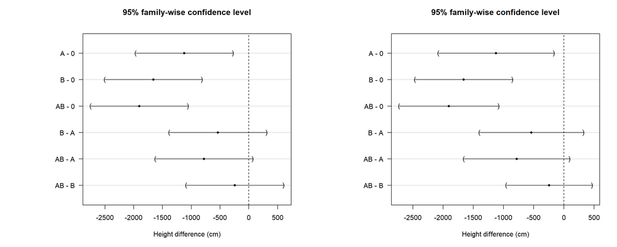

```r
par(mar = c(5, 10, 4, 2)+0.1, mfrow = c(1, 2))
HBW.comp %>% plot(xlab = "Height difference (cm)")
HBW.comp.hetero %>% plot(xlab = "Height difference (cm)")
```

```r
par(mar = c(5, 10, 4, 2)+0.1)
```

# Но я хочу доверительные интервалы! Post hoc анализ для гетероскедастичных данных.

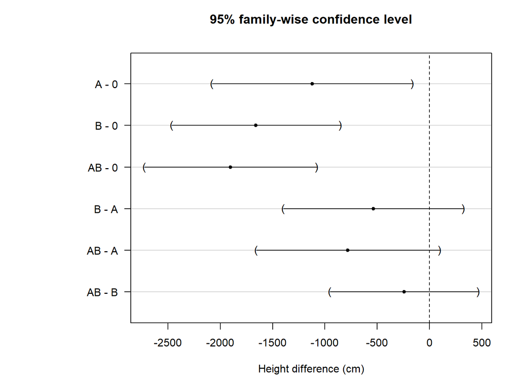

Для того, чтобы справиться с гетероскедастичностью, мы использовали так называемый sandwich estimator.

**Внимание:** сендвичи имеют обыкновение сходиться к реальной дисперсии снизу. На маленькой выборке риск ошибки первого рода повышен!